# Block 2 ex 1

Facchin Tommaso

Consider the dataset **wbca** from the **faraway** package. This dataset contains data from an oncological study aimed at determining whether a tumor is malignant or not using certain characteristics of cells extracted via a fine needle aspiration. See also `?faraway::wbca`.

```r
library(faraway)
data(wbca)
head(wbca)
```

```
##   Class Adhes BNucl Chrom Epith Mitos NNucl Thick UShap USize
## 1     1     1     1     3     2     1     1     5     1     1
## 2     1     5    10     3     7     1     2     5     4     4
## 3     1     1     2     3     2     1     1     3     1     1
## 4     1     1     4     3     3     1     7     6     8     8
## 5     1     3     1     3     2     1     1     4     1     1
## 6     0     8    10     9     7     1     7     8    10    10
```

### 1. Perform an initial estimation where the variable **Class** (the variable indicating the tumor classification) depends on the variable **Thick**. Produce a plot showing how the probability that a tumor is benign depends on **Thick**. Also, create a 96% confidence interval for the parameter associated with the variable **Thick**.

```r
fit1 <- glm(Class~Thick, data = wbca, family=binomial())
summary(fit1)
```

```
##
## Call:
## glm(formula = Class ~ Thick, family = binomial(), data = wbca)
##
## Coefficients:
##             Estimate Std. Error z value Pr(>|z|)
## (Intercept)  5.18199    0.38666   13.40   <2e-16 ***
## Thick       -0.94611    0.07591  -12.46   <2e-16 ***
## ---
## Signif. codes:  0 '***' 0.001 '**' 0.01 '*' 0.05 '.' 0.1 ' ' 1
##
## (Dispersion parameter for binomial family taken to be 1)
##
##     Null deviance: 881.39  on 680  degrees of freedom
## Residual deviance: 451.69  on 679  degrees of freedom
## AIC: 455.69
##
## Number of Fisher Scoring iterations: 6
```

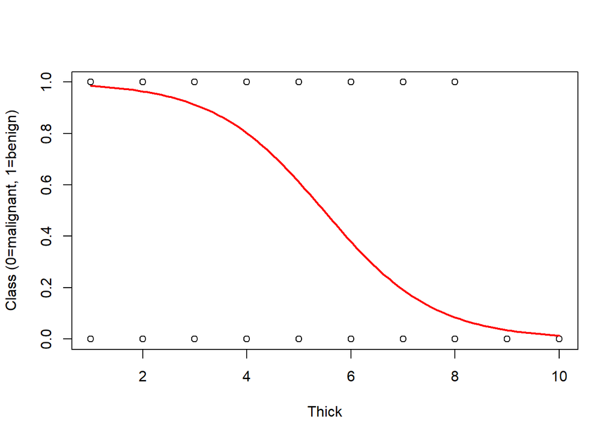

```r
thick_seq <- seq(min(wbca$Thick), max(wbca$Thick), length = 100)
newdat <- data.frame(Thick = thick_seq)
p_hat <- predict(fit1, newdata = newdat, type = "response")

plot(wbca$Thick, wbca$Class, xlab = "Thick", ylab = "Class (0=malignant, 1=benign)")
lines(thick_seq, p_hat, col = "red", lwd = 2)
```

```r
confint(fit1, parm = "Thick", level = 0.96)
```

```
## In attesa che venga eseguita la profilazione...
```

```
##        2 %       98 %
## -1.1132885 -0.8003731
```

### 2. Estimate a model where **Class** depends on all other variables available in the dataset. Obtain the residual deviance of the model and check whether the model has any predictive value. Also verify whether the model has better predictive ability than the one in which only **Thick** is used as a predictor.

```r
fitAll <- glm(Class~., data = wbca, family=binomial())
summary(fitAll)
```

```
##
## Call:
## glm(formula = Class ~ ., family = binomial(), data = wbca)
##
## Coefficients:
##             Estimate Std. Error z value Pr(>|z|)
## (Intercept) 11.16678    1.41491   7.892 2.97e-15 ***
## Adhes       -0.39681    0.13384  -2.965  0.00303 **
## BNucl       -0.41478    0.10230  -4.055 5.02e-05 ***
## Chrom       -0.56456    0.18728  -3.014  0.00257 **
## Epith       -0.06440    0.16595  -0.388  0.69795
## Mitos       -0.65713    0.36764  -1.787  0.07387 .
## NNucl       -0.28659    0.12620  -2.271  0.02315 *
## Thick       -0.62675    0.15890  -3.944 8.01e-05 ***
## UShap       -0.28011    0.25235  -1.110  0.26699
## USize        0.05718    0.23271   0.246  0.80589
## ---
## Signif. codes:  0 '***' 0.001 '**' 0.01 '*' 0.05 '.' 0.1 ' ' 1
##
## (Dispersion parameter for binomial family taken to be 1)
##
##     Null deviance: 881.388  on 680  degrees of freedom
## Residual deviance:  89.464  on 671  degrees of freedom
## AIC: 109.46
##
## Number of Fisher Scoring iterations: 8
```

In the full model the residual deviance is 89.46 on 671 degrees of freedom, which is much smaller than the null deviance (881.39), indicating that the model fits the data well and has substantial predictive power.

```r
anova(fit1, fitAll)
```

```
## Analysis of Deviance Table
##
## Model 1: Class ~ Thick
## Model 2: Class ~ Adhes + BNucl + Chrom + Epith + Mitos + NNucl + Thick +
##     UShap + USize
##   Resid. Df Resid. Dev Df Deviance
## 1       679     451.69
## 2       671      89.46  8   362.23
```

The analysis of deviance compares the model with only Thick to the full model and shows a reduction in residual deviance of 362.23 on 8 degrees of freedom, indicating that adding the other predictors leads to a highly significant improvement in model fit and predictive ability.

### 3. Use the **step** function to build a model that uses a subset of the available variables. Compare the models obtained when using **AIC** or **BIC** as criteria for selecting the subset of predictor variables to include in the model. If there are any differences between the models identified using the two criteria, explain the reason for such differences.

```r
n <- nrow(wbca)
lwr <- glm(Class~1, data = wbca, family=binomial())
upr <- glm(Class~., data = wbca, family=binomial())

fit_AIC <- step(object = lwr,
     scope = list(lower = lwr,
                  upper = upr),
     direction = "forward",
     k = 2
)
```

```
## Start:  AIC=883.39
## Class ~ 1
##
##         Df Deviance    AIC
## + USize  1   251.77 255.77
## + UShap  1   265.32 269.32
## + BNucl  1   331.46 335.46
## + Chrom  1   379.41 383.41
## + Epith  1   450.30 454.30
## + Thick  1   451.69 455.69
## + NNucl  1   454.76 458.76
## + Adhes  1   459.10 463.10
## + Mitos  1   713.09 717.09
## <none>       881.39 883.39
##
## Step:  AIC=255.77
## Class ~ USize
##
##         Df Deviance    AIC
## + BNucl  1   161.41 167.41
## + Thick  1   190.82 196.82
## + Chrom  1   200.26 206.26
## + NNucl  1   216.28 222.28
## + UShap  1   218.28 224.28
## + Adhes  1   224.84 230.84
## + Epith  1   236.32 242.32
## + Mitos  1   237.97 243.97
## <none>       251.77 255.77
##
## Step:  AIC=167.41
## Class ~ USize + BNucl
##
##         Df Deviance    AIC
## + Thick  1   127.76 135.76
## + NNucl  1   143.41 151.41
## + Chrom  1   144.09 152.09
## + UShap  1   148.43 156.43
## + Mitos  1   153.26 161.26
## + Adhes  1   155.48 163.48
## + Epith  1   156.64 164.64
```

[output cut: 36 more lines]

```
## Class ~ USize + BNucl + Thick + Chrom + Adhes + NNucl
##
##         Df Deviance    AIC
## + Mitos  1   90.923 106.92
## <none>       95.042 109.04
## + UShap  1   93.713 109.71
## + Epith  1   94.777 110.78
##
## Step:  AIC=106.92
## Class ~ USize + BNucl + Thick + Chrom + Adhes + NNucl + Mitos
##
##         Df Deviance    AIC
## <none>       90.923 106.92
## + UShap  1   89.613 107.61
## + Epith  1   90.627 108.63
```

```r
fit_BIC <- step(object = lwr,
     scope = list(lower = lwr,
                  upper = upr),
     direction = "forward",
     k = log(n)
)
```

```
## Start:  AIC=887.91
## Class ~ 1
##
##         Df Deviance    AIC
## + USize  1   251.77 264.82
## + UShap  1   265.32 278.37
## + BNucl  1   331.46 344.51
## + Chrom  1   379.41 392.45
## + Epith  1   450.30 463.35
## + Thick  1   451.69 464.74
## + NNucl  1   454.76 467.80
## + Adhes  1   459.10 472.15
## + Mitos  1   713.09 726.14
## <none>       881.39 887.91
##
## Step:  AIC=264.82
## Class ~ USize
##
##         Df Deviance    AIC
## + BNucl  1   161.41 180.98
## + Thick  1   190.82 210.40
## + Chrom  1   200.26 219.83
## + NNucl  1   216.28 235.86
## + UShap  1   218.28 237.85
## + Adhes  1   224.84 244.42
## + Epith  1   236.32 255.89
## + Mitos  1   237.97 257.54
## <none>       251.77 264.81
##
## Step:  AIC=180.98
## Class ~ USize + BNucl
##
##         Df Deviance    AIC
## + Thick  1   127.76 153.85
## + NNucl  1   143.41 169.51
## + Chrom  1   144.09 170.19
## + UShap  1   148.43 174.53
## + Mitos  1   153.26 179.36
## <none>       161.41 180.98
## + Adhes  1   155.48 181.57
```

[output cut: 28 more lines]

```
##         Df Deviance    AIC
## + NNucl  1   95.042 140.71
## <none>      102.608 141.75
## + Mitos  1   98.340 144.00
## + UShap  1  100.240 145.91
## + Epith  1  101.447 147.11
##
## Step:  AIC=140.71
## Class ~ USize + BNucl + Thick + Chrom + Adhes + NNucl
##
##         Df Deviance    AIC
## <none>       95.042 140.71
## + Mitos  1   90.923 143.11
## + UShap  1   93.713 145.90
## + Epith  1   94.777 146.97
```

```r
summary(fit_AIC)
```

```
##
## Call:
## glm(formula = Class ~ USize + BNucl + Thick + Chrom + Adhes +
##     NNucl + Mitos, family = binomial(), data = wbca)
##
## Coefficients:
##             Estimate Std. Error z value Pr(>|z|)
## (Intercept) 11.13859    1.38148   8.063 7.46e-16 ***
## USize       -0.15437    0.16250  -0.950  0.34211
## BNucl       -0.44818    0.09909  -4.523 6.10e-06 ***
## Thick       -0.66403    0.15747  -4.217 2.48e-05 ***
## Chrom       -0.58471    0.18285  -3.198  0.00139 **
## Adhes       -0.40624    0.13308  -3.053  0.00227 **
## NNucl       -0.31697    0.12282  -2.581  0.00986 **
## Mitos       -0.65261    0.35190  -1.855  0.06366 .
## ---
## Signif. codes:  0 '***' 0.001 '**' 0.01 '*' 0.05 '.' 0.1 ' ' 1
##
## (Dispersion parameter for binomial family taken to be 1)
##
##     Null deviance: 881.388  on 680  degrees of freedom
## Residual deviance:  90.923  on 673  degrees of freedom
## AIC: 106.92
##
## Number of Fisher Scoring iterations: 8
```

```r
summary(fit_BIC)
```

```
##
## Call:
## glm(formula = Class ~ USize + BNucl + Thick + Chrom + Adhes +
##     NNucl, family = binomial(), data = wbca)
##
## Coefficients:
##             Estimate Std. Error z value Pr(>|z|)
## (Intercept) 10.68108    1.28997   8.280  < 2e-16 ***
## USize       -0.18871    0.16313  -1.157  0.24734
## BNucl       -0.43928    0.09921  -4.428 9.53e-06 ***
## Thick       -0.75258    0.15594  -4.826 1.39e-06 ***
## Chrom       -0.56098    0.18146  -3.092  0.00199 **
## Adhes       -0.38892    0.13049  -2.980  0.00288 **
## NNucl       -0.31550    0.12109  -2.606  0.00917 **
## ---
## Signif. codes:  0 '***' 0.001 '**' 0.01 '*' 0.05 '.' 0.1 ' ' 1
##
## (Dispersion parameter for binomial family taken to be 1)
##
##     Null deviance: 881.388  on 680  degrees of freedom
## Residual deviance:  95.042  on 674  degrees of freedom
## AIC: 109.04
##
## Number of Fisher Scoring iterations: 8
```

Using forward stepwise selection with AIC (k = 2) the selected model includes the predictors USize, BNucl, Thick, Chrom, Adhes, NNucl and Mitos, with a residual deviance of 90.92 on 673 degrees of freedom (AIC = 106.92). In contrast, using BIC (k = log n) the selected model is more parsimonious and excludes Mitos, retaining only USize, BNucl, Thick, Chrom, Adhes and NNucl, with a slightly larger residual deviance of 95.04 on 674 degrees of freedom (AIC = 109.04). This difference arises because BIC applies a stronger penalty on model complexity than AIC, so it tends to prefer simpler models with fewer predictors even at the cost of a small loss in fit.

### 4. Using the model selected via **AIC**, estimate the probability that two patients with the characteristics indicated in the dataset **nd** have a benign tumor (i.e., a tumor with `Class = 1`). Provide a point estimate and a confidence interval estimate of this probability using a 96% confidence level. Comment on the width of the identified intervals.

```r
nd <- data.frame(
  Patient = c("A", "B"),
  Adhes = c(1, 3), BNucl = c(1, 3.5), Chrom = c(3, 3.5), Epith = c(2, 3.5),
  Mitos = c(1, 1.6), NNucl = c(1, 2.8), Thick = c(4, 4.43), UShap = c(1, 3.2),
  USize = c(1, 3.14)
)
```

```r
pred_link <- predict(fit_AIC, newdata = nd, type = "link", se.fit = TRUE)

fit  <- pred_link$fit
se   <- pred_link$se.fit

alpha <- 0.04
z     <- qnorm(1 - alpha/2)

lower_link <- fit - z * se
upper_link <- fit + z * se

p_hat   <- plogis(fit)
lower_p <- plogis(lower_link)
upper_p <- plogis(upper_link)

cbind(Patient = nd$Patient,
      p_hat, lower_p, upper_p)
```

```
##   Patient p_hat               lower_p             upper_p
## 1 "A"     "0.991422468483966" "0.972956382359351" "0.997314236708052"
## 2 "B"     "0.720453709176221" "0.564055668070906" "0.836961013807115"
```

Using the AIC‑selected model, the estimated probability of having a benign tumor is about 0.99 for patient A and 0.72 for patient B. The 96% confidence interval for patient A is very narrow [0.97, 1.00], indicating high precision and strong evidence that the probability of benign tumor is extremely large. For patient B the interval [0.56, 0.84] is wider, reflecting greater uncertainty in the prediction, although the probability of a benign tumor is still clearly above 0.5.